# Statistics for Bioengineering - Week 8

# Splines for Model Building

## From Exploration to Inference

Once LOESS reveals a non-linear relationship, you need formal tools to model it. Splines are **piecewise polynomials** that create smooth curves by fitting different segments between data points (knots).

**Types of Spline Fitting:**

- **Regression Splines** (`ns()`): Fit using least squares with specified knots — you choose the complexity
- **Smoothing Splines** (`smooth.spline()`): Balance data fidelity and smoothness automatically via cross-validation
- **GAMs** (`gam()` from mgcv): Generalized Additive Models — splines embedded in a regression framework, with automatic smoothness selection
- **Thin Plate Splines**: Extend to multiple dimensions for spatial data (e.g., scaffold thickness maps)

## Splines in R

- Code
- Key Points

```r
# Natural splines — you choose degrees of freedom
library(splines)
model_ns <- lm(y ~ ns(x, df = 4), data = mydata)

# Smoothing splines — CV selects smoothness
smooth_fit <- smooth.spline(x, y, cv = TRUE)

# GAMs — automatic smoothness selection
library(mgcv)
gam_model <- gam(y ~ s(x), data = mydata)

# Thin plate spline for 2D spatial data
model_tp <- gam(z ~ s(x, y, bs = "tp"), data = spatial_data)
```

- **Natural splines** constrain the tails to be linear — prevents dangerous extrapolation
- **GAMs** use `s()` with automatic smoothness selection via generalized cross-validation
- The **degrees of freedom** (df) control flexibility: df = 1 is linear, higher df = more wiggly
- For bioengineering dose-response curves, natural splines with 3–5 df are a good starting point

## Comparing Fitting Approaches

- Output
- Code
- Tradeoffs

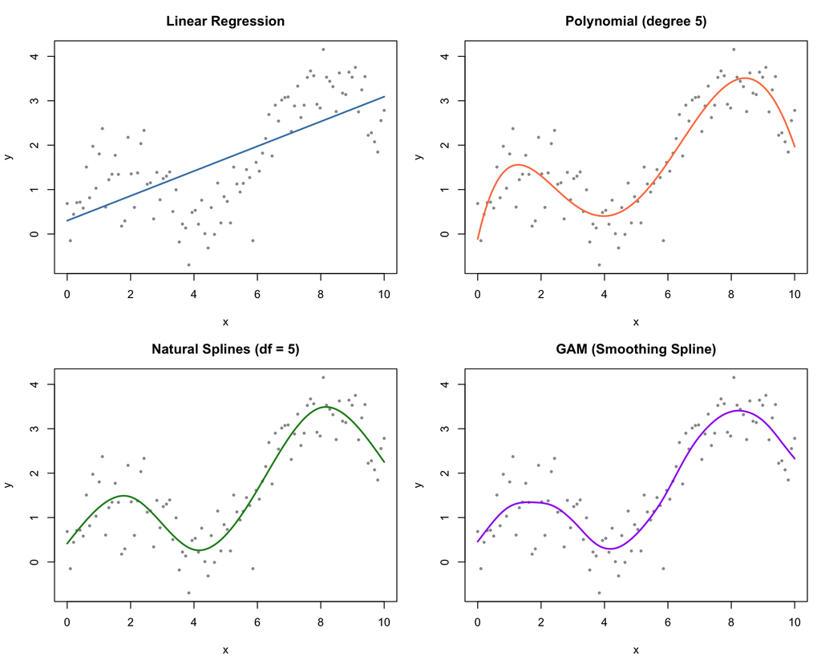

```r
library(splines)
par(mfrow = c(2, 2))

# Linear
m1 <- lm(y ~ x)
plot(x, y, pch = 16, col = "gray60", main = "Linear")
lines(x, predict(m1), col = "steelblue", lwd = 2)

# Polynomial
m2 <- lm(y ~ poly(x, 5))
plot(x, y, pch = 16, col = "gray60", main = "Polynomial (deg 5)")
lines(x, predict(m2), col = "coral", lwd = 2)

# Natural splines
m3 <- lm(y ~ ns(x, df = 5))
plot(x, y, pch = 16, col = "gray60", main = "Natural Splines (df=5)")
lines(x, predict(m3), col = "forestgreen", lwd = 2)

# GAM
m4 <- smooth.spline(x, y, cv = TRUE)
plot(x, y, pch = 16, col = "gray60", main = "GAM")
lines(m4, col = "purple", lwd = 2)
```

| Method | Flexibility | Extrapolation | Interpretability |
| --- | --- | --- | --- |
| Linear | Low | Reasonable | High |
| Polynomial | Medium | Dangerous | Medium |
| Natural splines | High | Linear tails | Medium |
| GAM | High | Auto-tuned | Lower |

# Survival Analysis

## What is Survival Analysis?

**Time-to-event analysis** — studying the time until an event occurs:

- Time until death (clinical trials)
- Time until device failure (bioengineering)
- Time until cell division or apoptosis
- Time until disease recurrence

**Key Features:**

- **Censoring**: Some subjects haven’t experienced the event yet
- **Non-normal data**: Time data is typically right-skewed
- **Hazard rates**: Instantaneous risk of the event at any given time

## Censoring in Survival Data

- Output
- Code

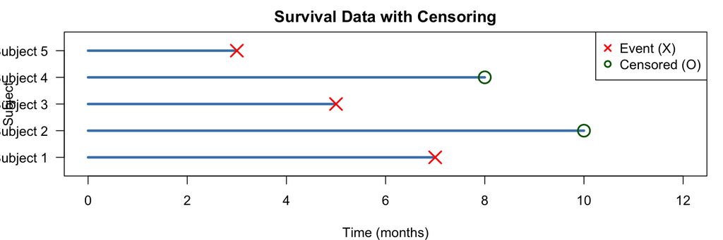

```r
par(mar = c(4, 4, 2, 1))
plot(NULL, xlim = c(0, 12), ylim = c(0.5, 5.5), xlab = "Time (months)",
     ylab = "Subject", main = "Survival Data with Censoring", yaxt = "n")
axis(2, at = 1:5, labels = paste("Subject", 1:5), las = 1)

segments(0, 5, 3, 5, lwd = 3, col = "steelblue")
points(3, 5, pch = 4, cex = 2, col = "red", lwd = 2)
segments(0, 4, 8, 4, lwd = 3, col = "steelblue")
points(8, 4, pch = 1, cex = 2, col = "darkgreen", lwd = 2)
# ... (additional subjects)

legend("topright", c("Event (X)", "Censored (O)"),
       pch = c(4, 1), col = c("red", "darkgreen"), pt.lwd = 2)
```

## The Survival and Hazard Functions

- Equations
- LaTeX

**Survival function:**
$$S(t) = P(T > t) = \text{Probability of surviving past time } t$$

- $S(0) = 1$ (everyone alive at start)
- $S(t)$ decreases over time
- $S(\infty) = 0$ (eventually everyone experiences the event)

**Hazard function:**
$$h(t) = \lim_{\Delta t \to 0} \frac{P(t \leq T < t + \Delta t \mid T \geq t)}{\Delta t}$$

```
S(t) = P(T > t)

h(t) = \lim_{\Delta t \to 0} \frac{P(t \leq T < t + \Delta t \mid T \geq t)}{\Delta t}
```

## Kaplan-Meier Estimator

The **product-limit estimator** for the survival function:

- Equation
- Code

$$\hat{S}(t) = \prod_{t_i \leq t} \left(1 - \frac{d_i}{n_i}\right)$$

Where $d_i$ = events at time $t_i$ and $n_i$ = number at risk before $t_i$

```r
library(survival)
data(lung)

# Fit Kaplan-Meier model
km_fit <- survfit(Surv(time, status) ~ 1, data = lung)

# Extract into data frame for ggplot2
km_df <- data.frame(time = km_fit$time, surv = km_fit$surv,
                     upper = km_fit$upper, lower = km_fit$lower)

# Plot with ggplot2
ggplot(km_df, aes(x = time, y = surv)) +
  geom_step(color = "steelblue", linewidth = 1.2) +
  geom_ribbon(aes(ymin = lower, ymax = upper),
              alpha = 0.2, fill = "steelblue") +
  geom_hline(yintercept = 0.5, lty = 2, color = "red") +
  labs(x = "Time (days)", y = "Survival Probability",
       title = "Kaplan-Meier Survival Curve")
```

## Kaplan-Meier Curves

- Output
- Code
- Explanation

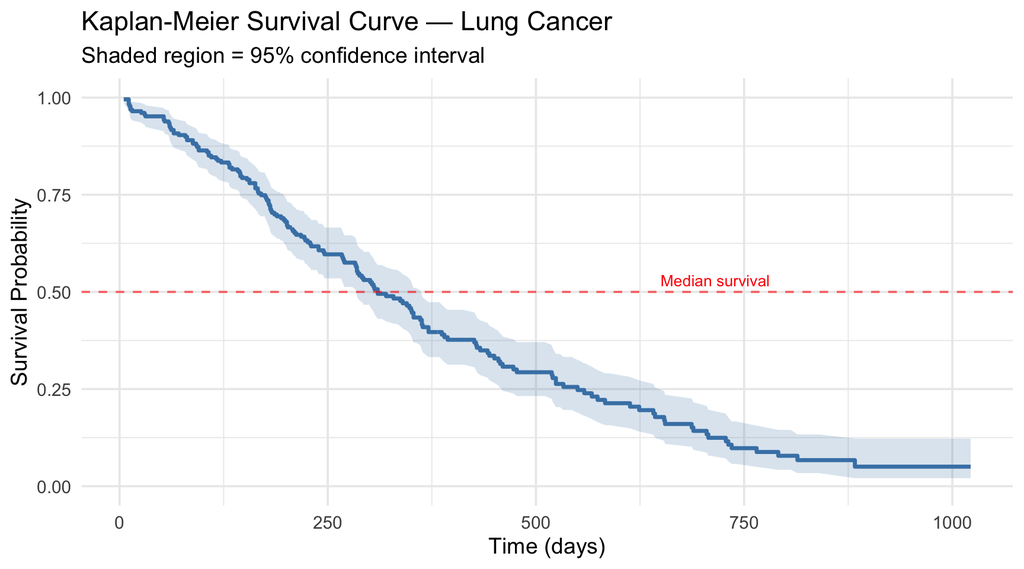

```r
library(survival)
data(lung)
km_fit <- survfit(Surv(time, status) ~ 1, data = lung)

# Extract into data frame for ggplot2
km_df <- data.frame(
  time = km_fit$time, surv = km_fit$surv,
  upper = km_fit$upper, lower = km_fit$lower
)

ggplot(km_df, aes(x = time, y = surv)) +
  geom_step(color = "steelblue", linewidth = 1.2) +
  geom_ribbon(aes(ymin = lower, ymax = upper),
              alpha = 0.2, fill = "steelblue") +
  geom_hline(yintercept = 0.5, lty = 2, color = "red") +
  labs(x = "Time (days)", y = "Survival Probability",
       title = "Kaplan-Meier Survival Curve")
```

- The **step function** reflects the discrete nature of survival estimation — the curve drops at each observed event time
- The **shaded ribbon** shows the 95% CI — wider at later times when fewer subjects remain at risk
- The **red dashed line** marks 50% survival — where it intersects the curve gives the median survival time
- Using ggplot2 instead of base R `plot.survfit()` gives you full control over aesthetics and makes it easy to add annotations

## Comparing Survival Curves

- Output
- Code
- Explanation

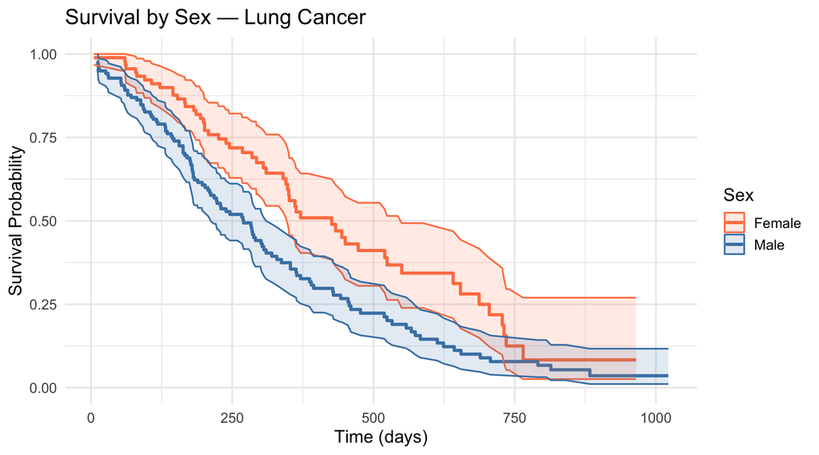

```r
km_sex <- survfit(Surv(time, status) ~ sex, data = lung)

# Extract and reshape for ggplot2
km_sex_df <- data.frame(
  time  = km_sex$time,
  surv  = km_sex$surv,
  upper = km_sex$upper,
  lower = km_sex$lower,
  group = rep(c("Male", "Female"), km_sex$strata)
)

ggplot(km_sex_df, aes(x = time, y = surv, color = group, fill = group)) +
  geom_step(linewidth = 1.2) +
  geom_ribbon(aes(ymin = lower, ymax = upper), alpha = 0.15) +
  scale_color_manual(values = c("Male" = "steelblue", "Female" = "coral")) +
  scale_fill_manual(values = c("Male" = "steelblue", "Female" = "coral")) +
  labs(x = "Time (days)", y = "Survival Probability",
       title = "Survival by Sex")
```

- Females show consistently higher survival probabilities — the coral curve stays above the blue curve
- The separation between curves suggests a sex effect, but we need a formal test (log-rank) to confirm
- Overlapping confidence ribbons in the early time period suggest the difference may not emerge immediately

## Log-Rank Test

Tests whether survival curves differ significantly between groups:

- Output
- Code

```
Call:
survdiff(formula = Surv(time, status) ~ sex, data = lung)

        N Observed Expected (O-E)^2/E (O-E)^2/V
sex=1 138      112     91.6      4.55      10.3
sex=2  90       53     73.4      5.68      10.3

 Chisq= 10.3  on 1 degrees of freedom, p= 0.001
```

```r
# Log-rank test comparing survival by sex
survdiff(Surv(time, status) ~ sex, data = lung)
```

## Cox Proportional Hazards Model

**Semi-parametric model** relating covariates to hazard:

- Equation
- Code

$$h(t \mid X) = h_0(t) \cdot \exp(\beta_1 X_1 + \beta_2 X_2 + \ldots)$$

Where $h_0(t)$ is the baseline hazard and $\exp(\beta)$ is the **hazard ratio** for a 1-unit increase.

```r
cox_model <- coxph(Surv(time, status) ~ age + sex + ph.ecog, data = lung)
summary(cox_model)
```

```
Call:
coxph(formula = Surv(time, status) ~ age + sex + ph.ecog, data = lung)

  n= 227, number of events= 164
   (1 observation deleted due to missingness)

             coef exp(coef)  se(coef)      z Pr(>|z|)
age      0.011067  1.011128  0.009267  1.194 0.232416
sex     -0.552612  0.575445  0.167739 -3.294 0.000986 ***
ph.ecog  0.463728  1.589991  0.113577  4.083 4.45e-05 ***
---
Signif. codes:  0 '***' 0.001 '**' 0.01 '*' 0.05 '.' 0.1 ' ' 1

        exp(coef) exp(-coef) lower .95 upper .95
age        1.0111     0.9890    0.9929    1.0297
sex        0.5754     1.7378    0.4142    0.7994
ph.ecog    1.5900     0.6289    1.2727    1.9864

Concordance= 0.637  (se = 0.025 )
Likelihood ratio test= 30.5  on 3 df,   p=1e-06
Wald test            = 29.93  on 3 df,   p=1e-06
Score (logrank) test = 30.5  on 3 df,   p=1e-06
```

## Interpreting Hazard Ratios

- Output
- Code
- Interpretation

```
               HR     2.5 %    97.5 %
age     1.0111282 0.9929281 1.0296620
sex     0.5754446 0.4142130 0.7994351
ph.ecog 1.5899912 1.2726752 1.9864236
```

```r
# Extract hazard ratios with confidence intervals
exp(cbind(HR = coef(cox_model), confint(cox_model)))
```

## Checking Proportional Hazards Assumption

- Output
- Code
- Explanation

```
        chisq df    p
age     0.188  1 0.66
sex     2.305  1 0.13
ph.ecog 2.054  1 0.15
GLOBAL  4.464  3 0.22
```

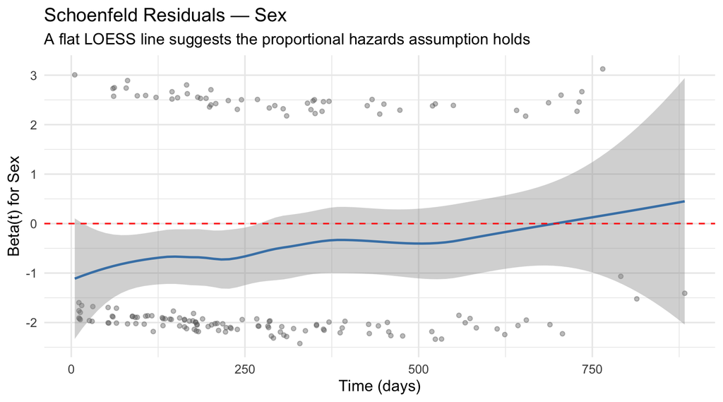

```r
# Test proportional hazards assumption
ph_test <- cox.zph(cox_model)
print(ph_test)  # p > 0.05 = assumption holds

# ggplot2 visualization of Schoenfeld residuals
ph_df <- data.frame(time = ph_test$time, beta = ph_test$y[, "sex"])
ggplot(ph_df, aes(x = time, y = beta)) +
  geom_point(alpha = 0.4) +
  geom_smooth(method = "loess", se = TRUE, color = "steelblue") +
  geom_hline(yintercept = 0, lty = 2, color = "red") +
  labs(x = "Time", y = "Beta(t) for Sex",
       title = "Schoenfeld Residuals — PH Check")
```

- The **Schoenfeld residual test** checks whether each covariate’s effect changes over time
- A non-significant p-value (> 0.05) means the proportional hazards assumption is reasonable
- In the plot, the LOESS smooth should be approximately flat and centered on zero — a trend indicates the hazard ratio changes over time
- If violated, consider: stratified Cox model, time-varying coefficients, or a different model entirely

## Bioengineering Example: Scaffold Degradation Survival

This example connects back to the scaffold degradation data from our mixed models analysis. Earlier we modeled degradation *rate* as a continuous outcome. Here we treat it as a time-to-event question: **how long until each scaffold loses 50% of its structural integrity?**

- Output
- Code
- Interpretation

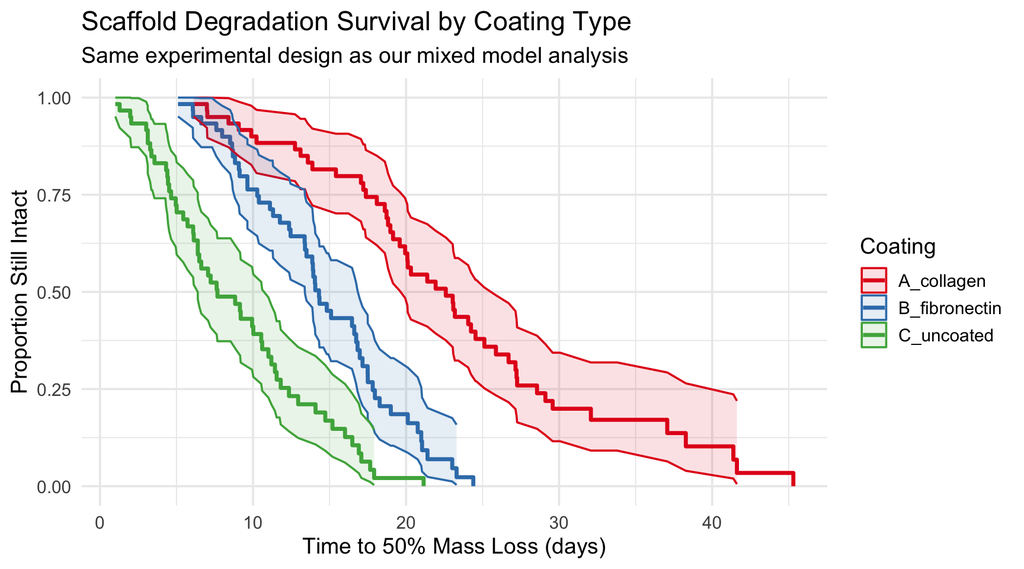

```r
# Using same treatment structure as our LMM scaffold dataset
# Now the outcome is time-to-50%-mass-loss (days)

km_scaffold <- survfit(Surv(time_to_50, event) ~ treatment,
                        data = scaffold_surv)

# Log-rank test: do coatings differ in degradation time?
survdiff(Surv(time_to_50, event) ~ treatment, data = scaffold_surv)

# Cox model: hazard ratios for coating types
cox_scaffold <- coxph(Surv(time_to_50, event) ~ treatment + temperature,
                       data = scaffold_surv)
summary(cox_scaffold)
exp(cbind(HR = coef(cox_scaffold), confint(cox_scaffold)))
```

## R Exercise: Logistic Regression

**Exercise**

A medical researcher wants to predict diabetes using blood glucose and BMI:

```r
# Simulated diabetes data
set.seed(123)
n <- 200
glucose <- rnorm(n, 100, 20)
bmi <- rnorm(n, 27, 5)
prob <- 1 / (1 + exp(-(-8 + 0.05 * glucose + 0.1 * bmi)))
diabetes <- rbinom(n, 1, prob)
diabetes_data <- data.frame(diabetes, glucose, bmi)
```

Tasks:

1. Fit logistic regression: `diabetes ~ glucose + bmi`
2. Interpret the odds ratios (exponentiated coefficients)
3. Predict probability of diabetes for glucose = 120, BMI = 30
4. Create a confusion matrix and calculate accuracy
5. What glucose level gives 50% probability (at mean BMI)?